# Just One Friend - Simulation Uncertainty

Jeanette Birnbaum

4/15/2020

# 1 “Original” full-code check

1. Put code that’s in the `"full-code"` chunk of SocDistNets.Rmd on Apr 15 at 2pm into a function (commit [6bc121a](https://github.com/statnet/COVID-JustOneFriend/commit/6bca21a57aa672cebe613843c328afef509c68e3)])
2. Add `set.seed=0` before `n <- 200`, as in the document
3. Check `largcomp.comp.2/200 = 0.71` - use this as an anchor statistic

The first time I run the original code taken from the full-code chunk, my target is 0.71 and I get 0.58. When I run it again, I get 0.58.

# 2 “Original” chunk-code check

Setting the seed allows replication of results, but why did I not hit the 0.71 target? Perhaps the full-code chunk is too out-of-date. Below is the code, aggregated from the chunks (same commit: [6bc121a](https://github.com/statnet/COVID-JustOneFriend/commit/6bca21a57aa672cebe613843c328afef509c68e3))

The first time I run the original code taken from the chunks combined, my target is 0.71 and I get 0.55. When I run it again, I get 0.55.

# 3 Multiple Simulations

I use `set.seed(0)` before fitting the models.

For some reason, knitting this would always hang. Instead, source `SocDistNets_SimUncertainty.R` in a fresh R session. The next code chunk shows that code, without evaluating. The chunk after that reads in the results.

## 3.1 Code (not evaluated)

```r
# Number of sims ----------------------------------
nsim <- 5

# Matrix for results ------------------------------
nets.to.loop <- c('Pre-Covid',
               'Essential Only', 'Just One Friend',
               'Just One Friend Per HH')
nets.to.loop.ids <- c('precov', 'essl', 'comb.1', 'comb.2')
empty.results.mat <- replicate(length(nets.to.loop), rep(NA,nsim))
colnames(empty.results.mat) <- nets.to.loop.ids
largest <- geo.3 <- geo.6 <- empty.results.mat

# Model Fits --------------------------------------
set.seed(0)
n <- 200
# Pre-Covid
emptynet <- network.initialize(n, directed=FALSE)
meandeg.precov <- 15
fit.precov <- ergm(emptynet~edges, target.stats=meandeg.precov*n/2)
# Essl
meandeg.essl <- 4
prop.essl <- 0.1
essl <- rep(0, n)
essl[sample(1:n, round(prop.essl*n,0), replace=FALSE)] <- 1
set.vertex.attribute(emptynet, 'essl', essl)
fit.essl <- ergm(emptynet~edges+ nodematch("essl", diff=TRUE, levels=1),
              target.stats= c(
                meandeg.essl*prop.essl*n, 0),
              control=control.ergm(MCMC.burnin = 1e6))
# non.essl.1
meandeg.non.essl.1 <- 2
fit.non.essl.1 <- ergm(emptynet~edges, target.stats= meandeg.non.essl.1*n/2)
# non.essl.2
meandeg.non.essl.2 <- 0.999
fit.non.essl.2 <- ergm(emptynet~edges+ concurrent, target.stats= c(meandeg.non.essl.2*n/2, 0))

# Chunk 3 - define geo.sep
geo.sep <- function(net, netname, distances=c(3,6)) {
  # Geodesic matrix - if not reachable, use NA
  geo.mat <- sna:::geodist(net, inf.replace=NA)$gdist
  # How many households are separated by distance x or less?
  # Do a node-based, not dyad-based, mean
  means <- sapply(distances, function(x) {
    geo.count <- (geo.mat<=x)
    # geo.count[lower.tri(geo.count, diag=TRUE)] <- NA
    diag(geo.count) <- NA
    return(mean(colSums(geo.count, na.rm=TRUE)))
  })

    return(means)
}

# Code Loop ---------------------------------------
# Have copied and pasted code from the aggregated chunks,
# removing the plotting and kpath calculations
start <- Sys.time()
for (i in 1:nsim) {

   # Chunk 2 - Pre-COVID
  net.precov <- simulate(fit.precov)
  largcomp.precov <- sum(component.largest(net.precov))


  # Chunk 4 - compute geo.precov
  geo.precov <-  geo.sep(net.precov)

  # Chunk 5 - plot emptynet

  # Chunk 6 - essl.net
  net.essl <- simulate(fit.essl, control = control.simulate(MCMC.burnin = 1e6))
  net.essl.el <- as.edgelist(net.essl)
  largcomp.essl <- sum(component.largest(net.essl))
  geo.essl <-  geo.sep(net.essl)

  # Chunk 7 - non.essl.net.1
  net.non.essl.1 <- simulate(fit.non.essl.1)
  net.comb.1 <- net.non.essl.1
  net.comb.1 <- add.edges(net.comb.1, tail=net.essl.el[,1], head=net.essl.el[,2])
  largcomp.comb.1 <- sum(component.largest(net.comb.1))
  geo.comb.1 <-  geo.sep(net.comb.1)

  # Chunk 8 - non.essl.net.2
  net.non.essl.2 <- simulate(fit.non.essl.2, control=control.simulate(MCMC.burnin=1e8))
  net.comb.2 <- net.non.essl.2
  net.comb.2 <- add.edges(net.comb.2, tail=net.essl.el[,1], head=net.essl.el[,2])
  largcomp.comb.2 <- sum(component.largest(net.comb.2))
  geo.comb.2 <-  geo.sep(net.comb.2)

  # Fill results matrices: largest
  largest[i,'precov'] <- largcomp.precov
  largest[i,'essl'] <- largcomp.essl
  largest[i,'comb.1'] <- largcomp.comb.1
  largest[i,'comb.2'] <- largcomp.comb.2

  # Fill results matrix: geo.3
  geo.3[i,'precov'] <- geo.precov[1]
  geo.3[i,'essl'] <- geo.essl[1]
  geo.3[i,'comb.1'] <- geo.comb.1[1]
  geo.3[i,'comb.2'] <- geo.comb.2[1]

  # Fill results matrix: geo.6
  geo.6[i,'precov'] <- geo.precov[2]
  geo.6[i,'essl'] <- geo.essl[2]
  geo.6[i,'comb.1'] <- geo.comb.1[2]
  geo.6[i,'comb.2'] <- geo.comb.2[2]

  if (i==1) append.logical <- FALSE else append.logical <- TRUE
  cat('\n',i,'....', as.character(Sys.time()),
      file='SocDistNets_SimUncertainty_Progress.txt', append=append.logical)
}
end <- Sys.time()
```

## 3.2 Read in sim results and melt for plotting

```r
largest <- read.csv('SocDistNets_SimUncertainty_100_largest.csv')
geo.3 <- read.csv('SocDistNets_SimUncertainty_100_geo.3.csv')
geo.6 <- read.csv('SocDistNets_SimUncertainty_100_geo.6.csv')

library(ggplot2)
library(reshape2)

largest_long <- melt(largest)
geo.3_long <- melt(geo.3)
geo.6_long <- melt(geo.6)
```

## 3.3 Runtime

Note that sourcing `SocDistNets_SimUncertainty.R` took 24 minutes.

## 3.4 Peek at distributions

Just showing the head of each results matrix - as a sanity check

Largest component

```r
head(largest)
```

|  | precov | essl | comb.1 | comb.2 |
| --- | --- | --- | --- | --- |
| 1 | 200 | 66 | 184 | 126 |
| 2 | 200 | 60 | 182 | 140 |
| 3 | 200 | 59 | 173 | 112 |
| 4 | 200 | 38 | 185 | 122 |
| 5 | 200 | 48 | 182 | 134 |
| 6 | 200 | 69 | 180 | 128 |

Three degrees of separation

```r
head(geo.3)
```

|  | precov | essl | comb.1 | comb.2 |
| --- | --- | --- | --- | --- |
| 1 | 199.00 | 5.50 | 34.49 | 13.23 |
| 2 | 198.99 | 4.37 | 28.15 | 11.68 |
| 3 | 199.00 | 3.56 | 32.73 | 9.77 |
| 4 | 198.96 | 3.97 | 31.25 | 11.00 |
| 5 | 198.99 | 3.60 | 28.74 | 9.89 |
| 6 | 198.99 | 4.02 | 35.56 | 11.95 |

Six degrees of separation

```r
head(geo.6)
```

|  | precov | essl | comb.1 | comb.2 |
| --- | --- | --- | --- | --- |
| 1 | 199 | 16.91 | 154.34 | 53.68 |
| 2 | 199 | 10.64 | 135.59 | 50.35 |
| 3 | 199 | 10.20 | 133.75 | 37.05 |
| 4 | 199 | 9.18 | 150.66 | 47.08 |
| 5 | 199 | 8.20 | 142.23 | 35.41 |
| 6 | 199 | 9.97 | 145.05 | 47.51 |

## 3.5 Largest component

Mean across 100 simulations:

```r
knitr::kable(
             data.frame(
                        largest.Mean=colMeans(largest),
                        largest.PercOf200=round(100*colMeans(largest)/200,1)
                        )
             )
```

|  | largest.Mean | largest.PercOf200 |
| --- | --- | --- |
| precov | 200.00 | 100.0 |
| essl | 59.83 | 29.9 |
| comb.1 | 181.48 | 90.7 |
| comb.2 | 125.43 | 62.7 |

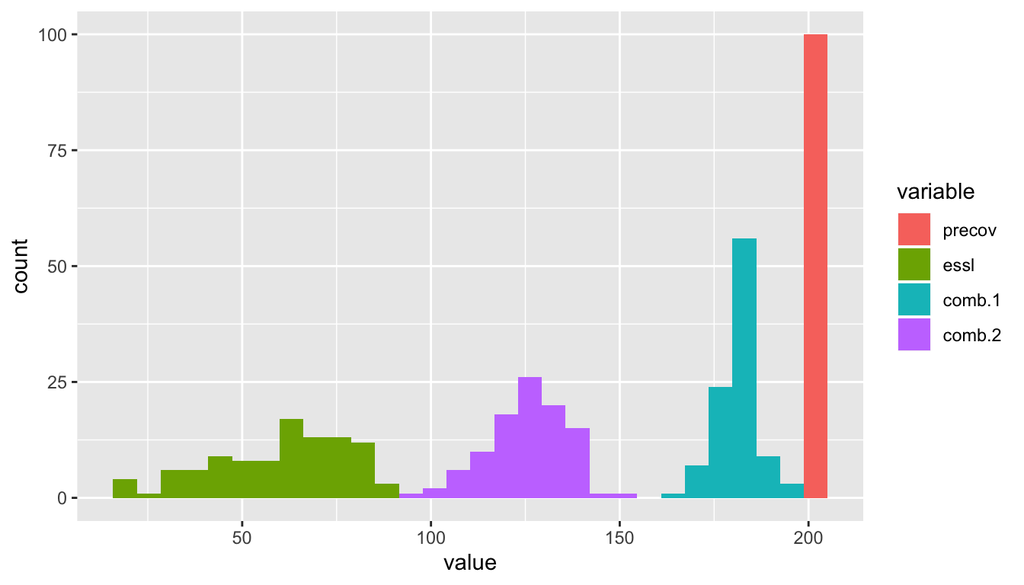

```r
ggplot(largest_long, aes(x=value, fill=variable)) + geom_histogram()
```

## 3.6 Three degrees of separation

Mean across 100 simulations:

```r
knitr::kable(data.frame(
                        geo.3.Mean=round(colMeans(geo.3),1),
                        geo.3.PercOf200=round(100*colMeans(geo.3)/200,1)
                        ))
```

|  | geo.3.Mean | geo.3.PercOf200 |
| --- | --- | --- |
| precov | 199.0 | 99.5 |
| essl | 4.7 | 2.3 |
| comb.1 | 33.5 | 16.8 |
| comb.2 | 11.9 | 6.0 |

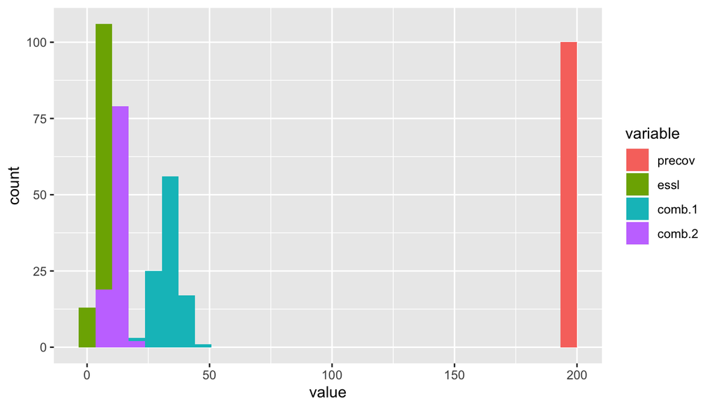

```r
ggplot(geo.3_long, aes(x=value, fill=variable)) + geom_histogram()
```

## 3.7 Six degrees of separation

Mean across 100 simulations:

```r
knitr::kable(data.frame(
                        geo.6.Mean=round(colMeans(geo.6),1),
                        geo.6.PercOf200=round(100*colMeans(geo.6)/200,1)
                        ))
```

|  | geo.6.Mean | geo.6.PercOf200 |
| --- | --- | --- |
| precov | 199.0 | 99.5 |
| essl | 13.4 | 6.7 |
| comb.1 | 145.7 | 72.9 |
| comb.2 | 48.5 | 24.2 |

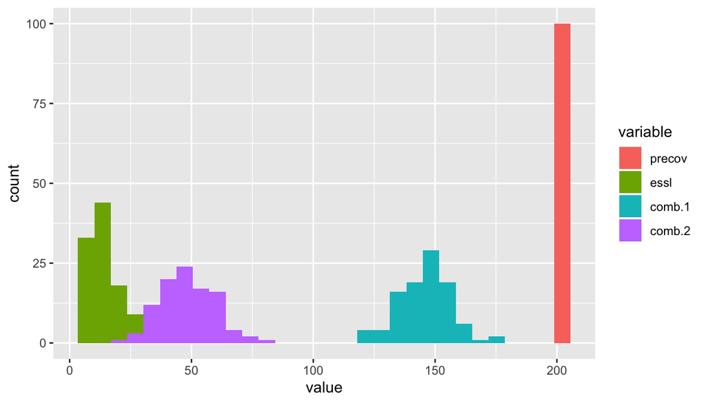

```r
ggplot(geo.6_long, aes(x=value, fill=variable)) + geom_histogram()
```